# ISLR 5: Resampling methods — Exercises

# Conceptual

## Question 2

We will now derive the probability that a given observation is part of a bootstrap sample. Suppose that we obtain a bootstrap sample from a set of $n$ observations. **(a)** What is the probability that the first bootstrap observation is not the *j*th observation from the original sample? Justify your answer.
$$P(b_1 \not= x_j) = 1-P(b_1 = x_j) = 1-\frac{1}{n}$$
Because each $b_i$ from the boostrap was sampled assuming a discrete uniform distribution from $\{x_1 \dots x_n \}$

**(b)** What is the probability that the second bootstrap observation is not the jth observation from the original sample? It’s just the same as above, since we are sampling with replacement.

**(c)** Argue that the probability that the *j*th observation is not in the bootstrap sample is $(1 − 1/n)^n$. Fixing j and varying $k$ in $[1,n] \cap \mathbb{N}$
$$P(x_j \not = b_k) = P(x_j \not = b_1 \wedge \dots \wedge x_j \not= b_n ) = P(x_j\not=b_1)\dots P(x_j \not= b_n) =
\left( 1 - \frac{1}{n} \right) ^n$$
Because the samples are independent from each other.

**(d)** When $n = 5$, what is the probability that the *j*th observation is in the bootstrap sample?

`r`r 1-(1-1/5)^5

```
[1] 0.67232
```

**(f)** When $n = 10,000$ what is the probability that the *j*th observation is in the bootstrap sample?

`r`r 1 -(1-1/10000)^10000

```
[1] 0.632139
```

**(g)** Create a plot that displays, for each integer value of $n$ from 1 to 100,000, the probability that the *j*th observation is in the bootstrap sample. Comment on what you observe.

`r`r x <- seq(1, 10000) y <- rep(1,10000) - (rep(1,10000) - 1/x)^x df <- data_frame(x = x, y = y) ggplot(df, aes(x = x, y = y)) + geom_point(alpha = 0.05)

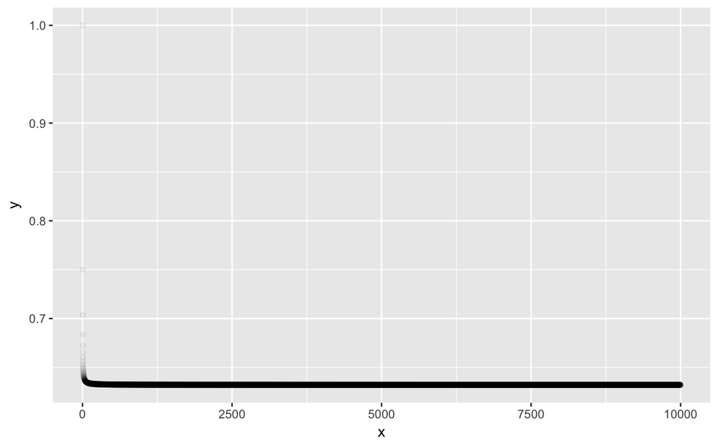

**(h)** We will now investigate numerically the probability that a bootstrap sample of size $n = 100$ contains the *j*th observation. Here $j = 4$. We repeatedly create bootstrap samples, and each time we record whether or not the fourth observation is contained in the bootstrap sample.

`r`r store <- rep(NA, 10000) for(j in 1:10000){ store[j] <- sum(base::sample(1:100, rep = TRUE) == 4) > 0 } mean(store)

```
[1] 0.6441
```

## Question 3

We now review k-fold cross-validation. **(a)** Explain how *k*-fold cross-validation is implemented. The data set is divided into *k* different nonoverlapping subsets of approximately the same size. Each one of those sets is used as a validation set, in the sense that the model is fitted *k* times, and in each one of them one of the folds is left out. The error is then calculated for every model and averaged along all values of *k*.

**(b)** What are the advantages and disadvantages of k-fold cross-validation relative to: i. the validation set approach *k*-fold has the advantage of reducing the bias of arbitrarily choosing just one validation set which tends to underestimate the true error of the model on the entire data set, but is $k-1$ times more computationally expensive. ii. LOOCV *k*-fold reduces the variance associated with LOOCV, which of course is greater because of the high overlap between training sets, which makes the different models correlated and the variance of the sum of correleated variables increases with covariance:
$$\mathrm{Var} \left[ \sum_{j = 1}n X_j \right] = \sum_{1 \leq i < j \leq n} \mathrm{Cov}(X_j,X_i)$$

## Question 4

Suppose that we use some statistical learning method to make a prediction for the response $Y$ for a particular value of the predictor $X$. Carefully describe how we might estimate the standard deviation of our prediction.

We can use the bootstrap method. To do this, we take $B$ samples of size $n$ (the size of the data set) of the original data (with replacement, of course) and train the model with each of the $B$ different data sets. We then calculate the deviation of each model and average across all of them.

# Applied (selected)

## Question 6

We continue to consider the use of a logistic regression model to predict the probability of `default` using `income` and `balance` on the Default data set. In particular, we will now compute estimates for the standard errors of the `income` and `balance` logistic regression coefficients in two different ways: (1) using the bootstrap, and (2) using the standard formula for computing the standard errors in the `glm()` function. Do not forget to set a random seed before beginning your analysis. Using the summary() and glm() functions, determine the esti- mated standard errors for the coefficients associated with income and balance in a multiple logistic regression model that uses both predictors.

**(a)** Using the `summary()` and `glm()` functions, determine the estimated standard errors for the coefficients associated with income and balance in a multiple logistic regression model that uses both predictors.

```r
glm_fit <- glm(default ~ income + balance,
               data = Default,
               family = binomial)
summary(glm_fit)
```

```
Call:
glm(formula = default ~ income + balance, family = binomial,
    data = Default)

Deviance Residuals:
    Min       1Q   Median       3Q      Max
-2.4725  -0.1444  -0.0574  -0.0211   3.7245

Coefficients:
              Estimate Std. Error z value Pr(>|z|)
(Intercept) -1.154e+01  4.348e-01 -26.545  < 2e-16 ***
income       2.081e-05  4.985e-06   4.174 2.99e-05 ***
balance      5.647e-03  2.274e-04  24.836  < 2e-16 ***
---
Signif. codes:  0 ‘***’ 0.001 ‘**’ 0.01 ‘*’ 0.05 ‘.’ 0.1 ‘ ’ 1

(Dispersion parameter for binomial family taken to be 1)

    Null deviance: 2920.6  on 9999  degrees of freedom
Residual deviance: 1579.0  on 9997  degrees of freedom
AIC: 1585

Number of Fisher Scoring iterations: 8
```

**(b)** Write a function, `boot_fn()`, that takes as input the Default data set as well as an index of the observations, and that outputs the coefficient estimates for income and balance in the multiple logistic regression model. (APPROACH USING `boot`)

```r
boot_fn <- function(data, index){
  model <- glm(default ~ income + balance,
               data = data,
               subset = index,
               family = binomial)
  return(coef(model))
}
```

**(c)** Use the `boot()` function together with your `boot.fn()` function to estimate the standard errors of the logistic regression coefficients for `income` and `balance.

```r
boot(Default, boot_fn, R = 1000)
```

```
ORDINARY NONPARAMETRIC BOOTSTRAP


Call:
boot(data = Default, statistic = boot_fn, R = 1000)


Bootstrap Statistics :
         original        bias     std. error
t1* -1.154047e+01 -5.219255e-02 4.383846e-01
t2*  2.080898e-05  1.607981e-07 4.736438e-06
t3*  5.647103e-03  2.619213e-05 2.312478e-04
```

**(d)** Comment on the estimated standard errors obtained using the `glm()` function and using your bootstrap function. The bootstrap approximation was pretty good.

**(e)** repeat (b) and (c) using the tidy approach.

| term | estimate | std_error |
| --- | --- | --- |
| (Intercept) | -1.158133e+01 | 4.374073e-01 |
| balance | 5.667366e-03 | 2.288158e-04 |
| income | 2.094573e-05 | 5.004695e-06 |

## Question 8

**(a)** Generate a simulated data set as follows:

```r
set.seed(1)
y <- rnorm(100)
x <- rnorm(100)
y <- x -2*x^2 + rnorm(100)
```

2. Create a scatterplot of $X$ against $Y$. Comment on what you find.

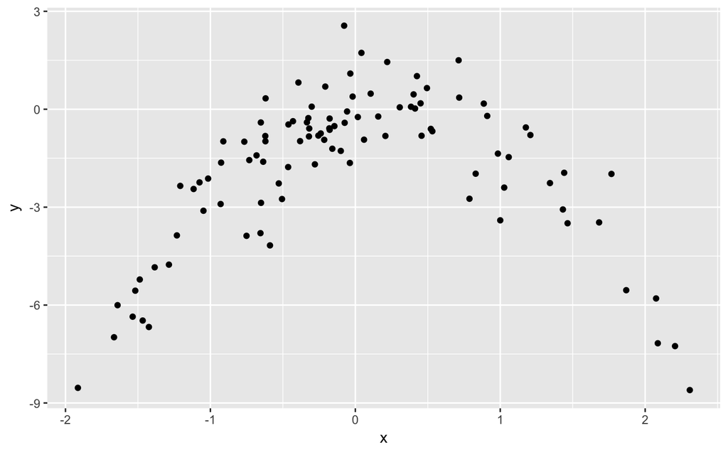

```r
data <- data_frame(x = x, y = y)
ggplot(data, aes(x = x, y = y)) +
  geom_point()
```

The data clearly looks like an upside down parabola. I expect the cuadratic polynomial to fit best.

**(c)** Set a random seed, and then compute the LOOCV errors that result from fitting, using least squares, polynomials of degrees one through of on x:

```r
set.seed(2283)
errors <- rep(0, 4)
for(d in 1:4){
  pold <- glm(y ~ poly(x, degree = d), data = data)
  errors[d] <- cv.glm(data, pold)$delta[1]
}
print(errors)
```

```
[1] 5.890979 1.086596 1.102585 1.114772
```

**(d)** Repeat (c) using another random seed, and report your results. Are your results the same as what you got in (c)? Why? They are the same. Since we are using LOOCV, there is absolutely nothing random about the process.

**(e)** Which of the models in (c) had the smallest LOOCV error? Is this what you expected? Explain your answer. As expected, the cuadratic polynomial that matches the true form of the data.

**(f)** Comment on the statistical significance of the coefficient estimates that results from fitting each of the models in (c) using least squares. Do these results agree with the conclusions drawn based on the cross-validation results?

```r
summary(glm(y ~ poly(x, 4)))
```

```
Call:
glm(formula = y ~ poly(x, 4))

Deviance Residuals:
    Min       1Q   Median       3Q      Max
-2.8914  -0.5244   0.0749   0.5932   2.7796

Coefficients:
            Estimate Std. Error t value Pr(>|t|)
(Intercept)  -1.8277     0.1041 -17.549   <2e-16 ***
poly(x, 4)1   2.3164     1.0415   2.224   0.0285 *
poly(x, 4)2 -21.0586     1.0415 -20.220   <2e-16 ***
poly(x, 4)3  -0.3048     1.0415  -0.293   0.7704
poly(x, 4)4  -0.4926     1.0415  -0.473   0.6373
---
Signif. codes:  0 ‘***’ 0.001 ‘**’ 0.01 ‘*’ 0.05 ‘.’ 0.1 ‘ ’ 1

(Dispersion parameter for gaussian family taken to be 1.084654)

    Null deviance: 552.21  on 99  degrees of freedom
Residual deviance: 103.04  on 95  degrees of freedom
AIC: 298.78

Number of Fisher Scoring iterations: 2
```